# Review 3 - Analysing Google Play Store applications

## Is there any work previously reported on the problem and the data? If so, discuss it here.

### Yes, there has been similar work done regarding this aspect but not on 2018 dataset

### link for the dataset

#### https://www.datacamp.com/projects/619

#### http://creativecommons.org/licenses/by/3.0/

## setup and library

```r
library(rmarkdown)
library(knitr)
library(tidyverse)
```

```r
library(highcharter)
library(lubridate)
library(stringr)
library(xts)
library(dplyr)
library(visdat)

library(readr)
library(ggplot2) #plots
#install.packages("teachingApps")
library(ggthemes)
library(teachingApps)
library(htmlwidgets)
```

## initialising the dataset

```r
data<-read.csv("D:\\play store\\googleplaystore.csv")
data2<-read.csv("D:\\play store\\googleplaystore_user_reviews.csv")
```

## Basic Commands to describe dataset

```r
glimpse(data)
```

```
## Rows: 10,841
## Columns: 13
## $ App            <chr> "Photo Editor & Candy Camera & Grid & ScrapBook", "C...
## $ Category       <chr> "ART_AND_DESIGN", "ART_AND_DESIGN", "ART_AND_DESIGN"...
## $ Rating         <dbl> 4.1, 3.9, 4.7, 4.5, 4.3, 4.4, 3.8, 4.1, 4.4, 4.7, 4....
## $ Reviews        <chr> "159", "967", "87510", "215644", "967", "167", "178"...
## $ Size           <chr> "19M", "14M", "8.7M", "25M", "2.8M", "5.6M", "19M", ...
## $ Installs       <chr> "10,000+", "500,000+", "5,000,000+", "50,000,000+", ...
## $ Type           <chr> "Free", "Free", "Free", "Free", "Free", "Free", "Fre...
## $ Price          <chr> "0", "0", "0", "0", "0", "0", "0", "0", "0", "0", "0...
## $ Content.Rating <chr> "Everyone", "Everyone", "Everyone", "Teen", "Everyon...
## $ Genres         <chr> "Art & Design", "Art & Design;Pretend Play", "Art & ...
## $ Last.Updated   <chr> "January 7, 2018", "January 15, 2018", "August 1, 20...
## $ Current.Ver    <chr> "1.0.0", "2.0.0", "1.2.4", "Varies with device", "1....
## $ Android.Ver    <chr> "4.0.3 and up", "4.0.3 and up", "4.0.3 and up", "4.2...
```

```r
str(data)
```

```
## 'data.frame':    10841 obs. of  13 variables:
##  $ App           : chr  "Photo Editor & Candy Camera & Grid & ScrapBook" "Coloring book moana" "U Launcher Lite â\200“ FREE Live Cool Themes, Hide Apps" "Sketch - Draw & Paint" ...
##  $ Category      : chr  "ART_AND_DESIGN" "ART_AND_DESIGN" "ART_AND_DESIGN" "ART_AND_DESIGN" ...
##  $ Rating        : num  4.1 3.9 4.7 4.5 4.3 4.4 3.8 4.1 4.4 4.7 ...
##  $ Reviews       : chr  "159" "967" "87510" "215644" ...
##  $ Size          : chr  "19M" "14M" "8.7M" "25M" ...
##  $ Installs      : chr  "10,000+" "500,000+" "5,000,000+" "50,000,000+" ...
##  $ Type          : chr  "Free" "Free" "Free" "Free" ...
##  $ Price         : chr  "0" "0" "0" "0" ...
##  $ Content.Rating: chr  "Everyone" "Everyone" "Everyone" "Teen" ...
##  $ Genres        : chr  "Art & Design" "Art & Design;Pretend Play" "Art & Design" "Art & Design" ...
##  $ Last.Updated  : chr  "January 7, 2018" "January 15, 2018" "August 1, 2018" "June 8, 2018" ...
##  $ Current.Ver   : chr  "1.0.0" "2.0.0" "1.2.4" "Varies with device" ...
##  $ Android.Ver   : chr  "4.0.3 and up" "4.0.3 and up" "4.0.3 and up" "4.2 and up" ...
```

```r
dim(data)
```

```
## [1] 10841    13
```

```r
head(data)
```

```
##                                                    App       Category Rating
## 1       Photo Editor & Candy Camera & Grid & ScrapBook ART_AND_DESIGN    4.1
## 2                                  Coloring book moana ART_AND_DESIGN    3.9
## 3 U Launcher Lite â\200“ FREE Live Cool Themes, Hide Apps ART_AND_DESIGN    4.7
## 4                                Sketch - Draw & Paint ART_AND_DESIGN    4.5
## 5                Pixel Draw - Number Art Coloring Book ART_AND_DESIGN    4.3
## 6                           Paper flowers instructions ART_AND_DESIGN    4.4
##   Reviews Size    Installs Type Price Content.Rating                    Genres
## 1     159  19M     10,000+ Free     0       Everyone              Art & Design
## 2     967  14M    500,000+ Free     0       Everyone Art & Design;Pretend Play
## 3   87510 8.7M  5,000,000+ Free     0       Everyone              Art & Design
## 4  215644  25M 50,000,000+ Free     0           Teen              Art & Design
## 5     967 2.8M    100,000+ Free     0       Everyone   Art & Design;Creativity
## 6     167 5.6M     50,000+ Free     0       Everyone              Art & Design
##       Last.Updated        Current.Ver  Android.Ver
## 1  January 7, 2018              1.0.0 4.0.3 and up
## 2 January 15, 2018              2.0.0 4.0.3 and up
## 3   August 1, 2018              1.2.4 4.0.3 and up
## 4     June 8, 2018 Varies with device   4.2 and up
## 5    June 20, 2018                1.1   4.4 and up
## 6   March 26, 2017                1.0   2.3 and up
```

```r
summary(data)
```

```
##      App              Category             Rating         Reviews
##  Length:10841       Length:10841       Min.   : 1.000   Length:10841
##  Class :character   Class :character   1st Qu.: 4.000   Class :character
##  Mode  :character   Mode  :character   Median : 4.300   Mode  :character
##                                        Mean   : 4.193
##                                        3rd Qu.: 4.500
##                                        Max.   :19.000
##                                        NA's   :1474
##      Size             Installs             Type              Price
##  Length:10841       Length:10841       Length:10841       Length:10841
##  Class :character   Class :character   Class :character   Class :character
##  Mode  :character   Mode  :character   Mode  :character   Mode  :character
##
##
##
##
##  Content.Rating        Genres          Last.Updated       Current.Ver
##  Length:10841       Length:10841       Length:10841       Length:10841
##  Class :character   Class :character   Class :character   Class :character
##  Mode  :character   Mode  :character   Mode  :character   Mode  :character
##
##
##
##
##  Android.Ver
##  Length:10841
##  Class :character
##  Mode  :character
##
##
##
##
```

```r
colnames(data)
```

```
##  [1] "App"            "Category"       "Rating"         "Reviews"
##  [5] "Size"           "Installs"       "Type"           "Price"
##  [9] "Content.Rating" "Genres"         "Last.Updated"   "Current.Ver"
## [13] "Android.Ver"
```

```r
glimpse(data2)
```

```
## Rows: 64,295
## Columns: 5
## $ App                    <chr> "10 Best Foods for You", "10 Best Foods for ...
## $ Translated_Review      <chr> "I like eat delicious food. That's I'm cooki...
## $ Sentiment              <chr> "Positive", "Positive", "nan", "Positive", "...
## $ Sentiment_Polarity     <dbl> 1.0000000, 0.2500000, NaN, 0.4000000, 1.0000...
## $ Sentiment_Subjectivity <dbl> 0.5333333, 0.2884615, NaN, 0.8750000, 0.3000...
```

```r
colnames(data2)
```

```
## [1] "App"                    "Translated_Review"      "Sentiment"
## [4] "Sentiment_Polarity"     "Sentiment_Subjectivity"
```

## first, we take a look at all the missing values of the dataset

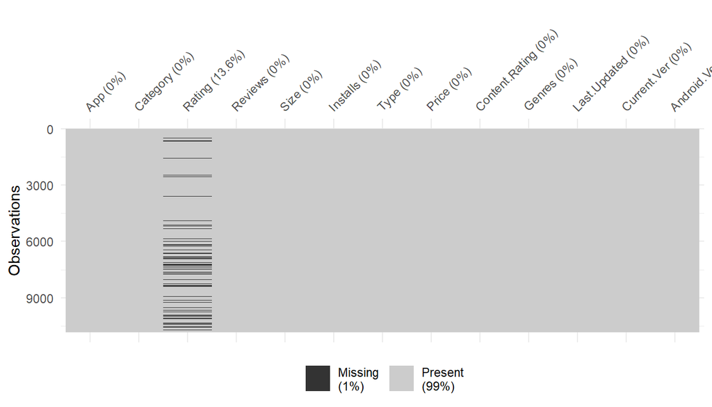

```r
vis_miss(data)
```

```r
summary(data$Rating)
```

```
##    Min. 1st Qu.  Median    Mean 3rd Qu.    Max.    NA's
##   1.000   4.000   4.300   4.193   4.500  19.000    1474
```

### we see that max rating of apps goes on till 19 while google allows you to rate out of 5. so we need to take care of this before we move further.

```r
data.Rating <- data[which(data$Rating > 5),] <- NA
summary(data$Rating)
```

```
##    Min. 1st Qu.  Median    Mean 3rd Qu.    Max.    NA's
##   1.000   4.000   4.300   4.192   4.500   5.000    1475
```

## Data Preprocessing

### upon checking the dataset, we see there are multiple NA or empty values and we need to clean the dataset to do analysis on it. also, there are a lot of factor variables which will be converted into numeric so that analysis on them becomes easier.

```r
data.clean <- data %>%
  mutate(
    # Eliminate some characters to transform Installs to numeric
    Installs = gsub("\\+", "", as.character(Installs)),
    Installs = as.numeric(gsub(",", "", Installs)),
    # Eliminate M to transform Size to numeric
    Size = gsub("M", "", Size),
    # Replace cells with k to 0 since it is < 1MB
    Size = ifelse(grepl("k", Size), 0, as.numeric(Size)),
    # Transform reviews to numeric
    Reviews = as.numeric(Reviews),
    # Remove currency symbol from Price, change it to numeric
    Price = as.numeric(gsub("\\$", "", as.character(Price))),
    # Last Updated to date format
    Last.Updated = mdy(Last.Updated),
    # Replace "Varies with device" to NA since it is unknown
    Min.Android.Ver = gsub("Varies with device", NA, Android.Ver),
    # Keep only version number to 1 decimal
    Min.Android.Ver = as.numeric(substr(Min.Android.Ver, start = 1, stop = 3)),
    # Drop old Android version column
    Android.Ver = NULL
  ) %>%
  filter(
    # Two apps had type as 0 or NA, they will be removed
    Type %in% c("Free", "Paid")
  )
str(data.clean)
```

```
## 'data.frame':    10839 obs. of  13 variables:
##  $ App            : chr  "Photo Editor & Candy Camera & Grid & ScrapBook" "Coloring book moana" "U Launcher Lite â\200“ FREE Live Cool Themes, Hide Apps" "Sketch - Draw & Paint" ...
##  $ Category       : chr  "ART_AND_DESIGN" "ART_AND_DESIGN" "ART_AND_DESIGN" "ART_AND_DESIGN" ...
##  $ Rating         : num  4.1 3.9 4.7 4.5 4.3 4.4 3.8 4.1 4.4 4.7 ...
##  $ Reviews        : num  159 967 87510 215644 967 ...
##  $ Size           : num  19 14 8.7 25 2.8 5.6 19 29 33 3.1 ...
##  $ Installs       : num  1e+04 5e+05 5e+06 5e+07 1e+05 5e+04 5e+04 1e+06 1e+06 1e+04 ...
##  $ Type           : chr  "Free" "Free" "Free" "Free" ...
##  $ Price          : num  0 0 0 0 0 0 0 0 0 0 ...
##  $ Content.Rating : chr  "Everyone" "Everyone" "Everyone" "Teen" ...
##  $ Genres         : chr  "Art & Design" "Art & Design;Pretend Play" "Art & Design" "Art & Design" ...
##  $ Last.Updated   : Date, format: "2018-01-07" "2018-01-15" ...
##  $ Current.Ver    : chr  "1.0.0" "2.0.0" "1.2.4" "Varies with device" ...
##  $ Min.Android.Ver: num  4 4 4 4.2 4.4 2.3 4 4.2 3 4 ...
```

```r
#summary(data.clean$Rating)
```

## data with NA values

```r
data.clean %>%
    summarise_all(
        funs(sum(is.na(.)))
    ) %>%
  gather() %>%
  # Only show columns with NA
  filter(value> 1) %>%
  arrange(-value) %>%
    hchart('column', hcaes(x = 'key', y = 'value', color = 'key')) %>%
  hc_add_theme(hc_theme_elementary()) %>%
  hc_title(text = "Columns with NA values")
```

[interactive chart not shown]

## most popular category by the number of installs

```r
data.clean %>%
  count(Category, Installs) %>%
  group_by(Category) %>%
  summarize(TotalInstalls = sum(as.numeric(Installs))
  )%>%
  arrange(-TotalInstalls) %>%
  hchart('scatter', hcaes(x = "Category", y = "TotalInstalls", size = "TotalInstalls", color = "Category")) %>%
  hc_add_theme(hc_theme_ft()) %>%
  hc_title(text = "Most popular categories (Number of installs)")
```

[interactive chart not shown]

## now we focus on application size in terms of MB

```r
data.clean %>%
  count(Size) %>%
  hchart('scatter', hcaes(x = "Size", y = "n")) %>%
  hc_colors("#5DE336") %>%
  hc_add_theme(hc_theme_gridlight()) %>%
  hc_title(text = "Distribution of application size (in MB)")
```

[interactive chart not shown]

#### There are a lot of apps under 10MB, in general applications are between 5 MB to 20 MB.

## free vs paid app

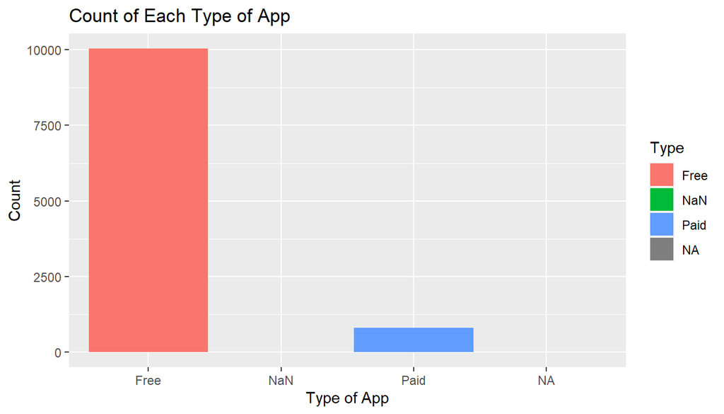

```r
ggplot(data,aes(x=Type,fill=Type)) +
  geom_bar()+
  ggtitle("Count of Each Type of App")+
  xlab("Type of App")+
  ylab("Count")
```

## lets take a look at the distribution of free and paid applications

```r
tmp <- data.clean %>%
  count(Type) %>%
  mutate(perc = round((n /sum(n))*100)) %>%
  arrange(desc(perc))

hciconarray(tmp$Type, tmp$perc, size = 5) %>%
  hc_title(text="Percentage of paid vs free apps")
```

[interactive chart not shown]

## Distribution of free vs paid apps by category

```r
data.clean %>%
  group_by(Category, Type) %>%
  summarize(
    n = n()
  ) %>%
  mutate(perc = round((n /sum(n))*100)) %>%
  hchart('bar', hcaes(x = 'Category', y = 'perc', group = 'Type')) %>%
  hc_plotOptions(series=list(stacking='normal')) %>%
  hc_title(text="Percentage of Free vs Paid by Category") %>%
  hc_add_theme(hc_theme_flat())
```

[interactive chart not shown]

## Analyzing all apps with respect to their pricing per category. the distribtuion is done by comparing it to median as mean could skew the values a lot

```r
data.clean %>%
  filter(Type == "Paid") %>%
  group_by(Category) %>%
  summarize(
    Price = mean(Price)
  ) %>%
  arrange(-Price) %>%
  hchart('treemap', hcaes(x = 'Category', value = 'Price', color = 'Price')) %>%
  hc_add_theme(hc_theme_elementary()) %>%
  hc_title(text="Mean Price Distrubtion per category")
```

[interactive chart not shown]

```r
data.clean %>%
  filter(Type == "Paid") %>%
  group_by(Category) %>%
  summarize(
    Price = median(Price)
  ) %>%
  arrange(-Price) %>%
  hchart('treemap', hcaes(x = 'Category', value = 'Price', color = 'Price')) %>%
  hc_add_theme(hc_theme_elementary()) %>%
  hc_title(text=" Median Price Distrubtion per category")
```

[interactive chart not shown]

## analysing apps based on when they were updated by year

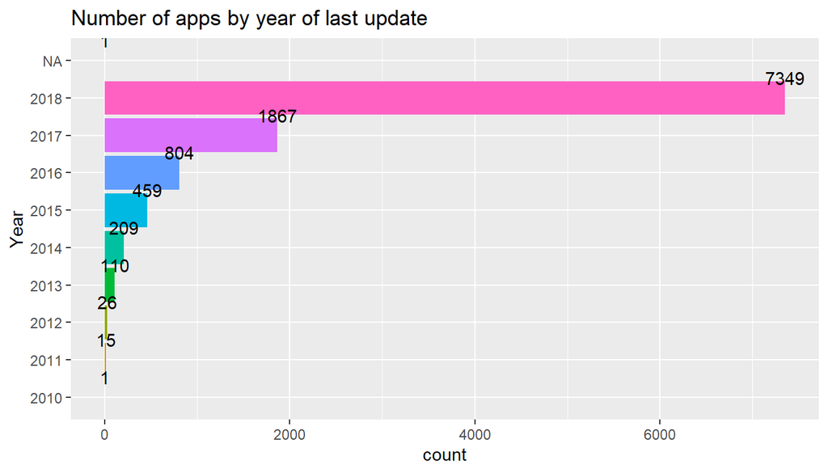

```r
## Split the date into day, month and year.
## With that we could have a good visalization of last updated column
dates <- str_split(str_remove_all(data$Last.Updated, ",")," ")
months <- sapply(dates, function(t){return (paste(t[1],t[3],sep = " "))})
days <- sapply(dates, function(t){return (t[2])})
years <- sapply(dates, function(t){return (t[3])})
last_update <- data.frame(months = months, years = years)
## BarPlot for year of Last.Updated
ggplot(last_update, aes(x = years, fill = years)) +
  geom_bar() +
  geom_text(stat='count', aes(label=..count..), vjust=-1) +
  guides(fill = FALSE) +
  xlab("Year") +
  labs(title = "Number of apps by year of last update")+coord_flip()
```

## analyzing apps based on when they were last updated by exact date

```r
# Get number of apps by last updated date
tmp <- data.clean %>% count(Last.Updated)

# Transform data into time series
time_series <- xts(
  tmp$n, order.by = tmp$Last.Updated
)

highchart(type = "stock") %>%
  hc_title(text = "Last updated date") %>%
  hc_subtitle(text = "Number of applications by date of last update") %>%
  hc_add_series(time_series) %>%
  hc_add_theme(hc_theme_gridlight())
```

[interactive chart not shown]

## based on their android version

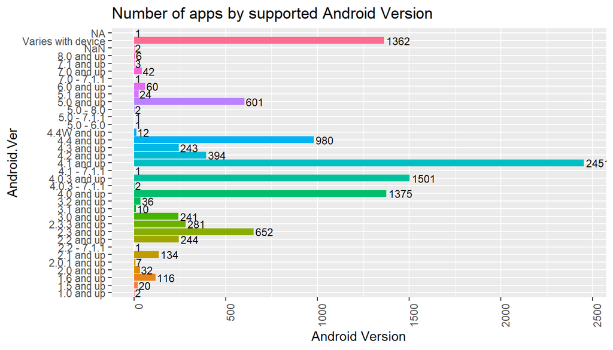

```r
## BarPlot
ggplot(data, aes(x = Android.Ver, fill = Android.Ver)) +
  geom_bar() +
  theme(axis.text.x = element_text(angle = 90, hjust = 1)) +
  geom_text(stat='count', aes(label=..count..), vjust=0.5, hjust = -0.1, size=3)+
  coord_flip() + labs(title="Number of apps by supported Android Version") + guides(fill = FALSE) +
  ylab("Android Version")
```

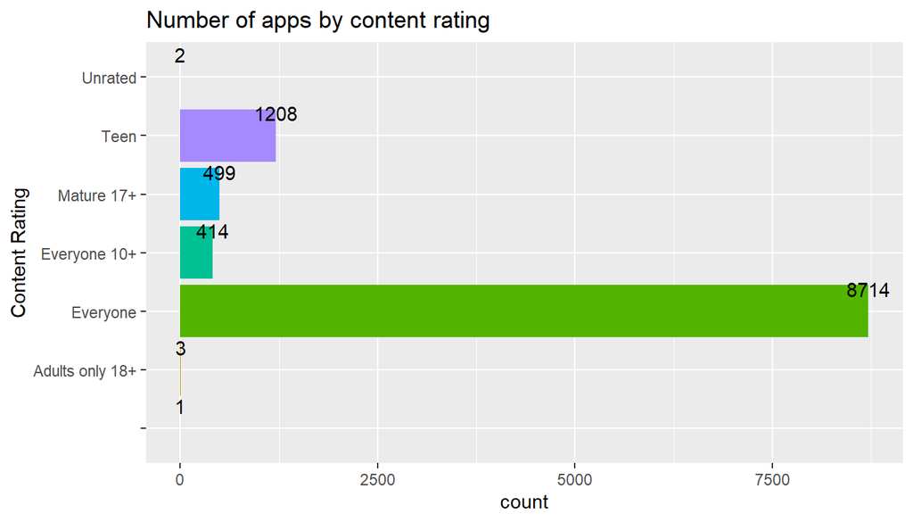

```r
## content rating column
googleplaystore<-read.csv("D:\\play store\\googleplaystore.csv")
## Bar_Plot
ggplot(googleplaystore, aes(x = Content.Rating, fill = Content.Rating)) +
  geom_bar() +
  geom_text(stat='count', aes(label=..count..), vjust=-1) +
  guides(fill = FALSE) +
  labs(title = "Number of apps by content rating") +
  xlab("Content Rating")+coord_flip()
```

## number of installs per category

```r
n_installs<-data.clean%>%group_by(Category)%>%summarise(installs=sum(Installs,na.rm = TRUE))%>%ungroup()
```

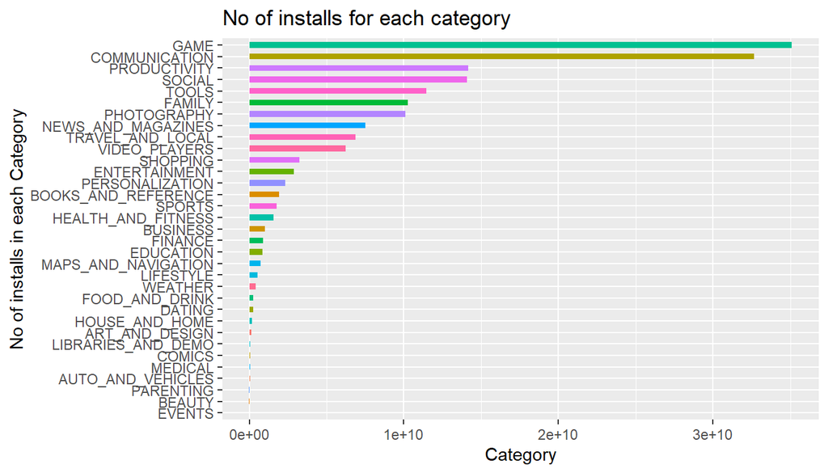

```r
p<-ggplot(n_installs,aes(x=reorder(Category,installs),y=installs,fill=Category))+geom_bar(stat = "identity",width =0.5)+coord_flip()+labs(x="No of installs in each Category",y="Category",title="No of installs for each category")
p+theme(legend.position = "None")
```

#### here we see that games are the most installed apps on playstore

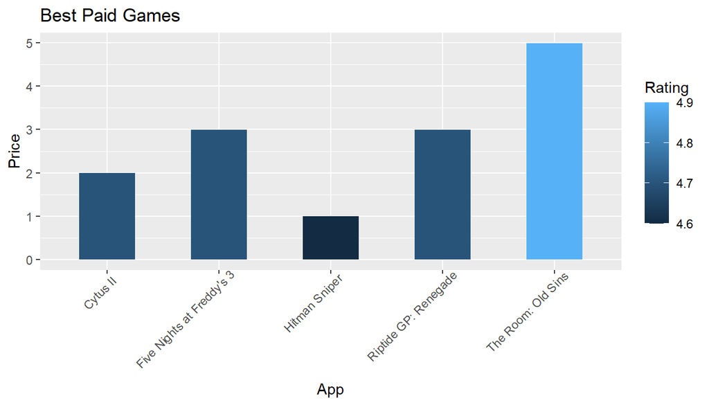

```r
#Best Paid Games
p_games <- data.clean%>%filter(Category=="GAME"  & Type=="Paid" & Rating>=4.0 &Installs>10000) %>% select(App,Price,Rating)%>%arrange(desc(Rating),Price)
p<-ggplot(p_games[1:5,],aes(x=App,y=Price,fill=Rating))+geom_bar(stat="identity",width = 0.5)
p+labs(title="Best Paid Games")+theme(axis.text.x = element_text(angle = 45,hjust = 0.9))
```

## no of apps by genre in game category

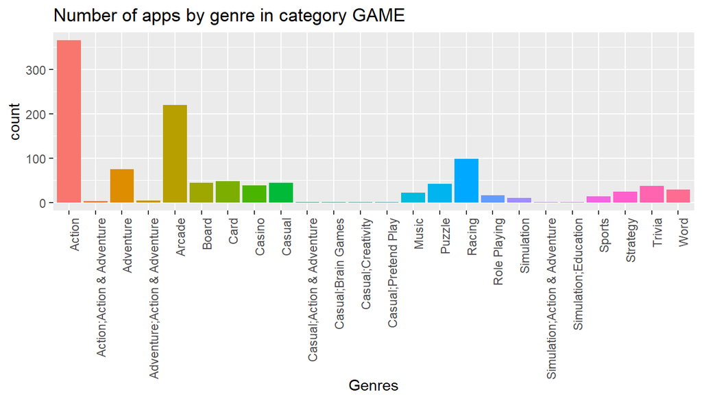

```r
## Bar_Plot For GAME Category
ggplot(googleplaystore[googleplaystore$Category %in% c('GAME'),], aes(x = Genres, fill = Genres)) +
  geom_bar() +
  theme(axis.text.x = element_text(angle = 90, hjust = 1))  +
  labs(title = "Number of apps by genre in category GAME") +
  guides(fill = FALSE)
```

## checking which category has the most positive reviews

```r
xx<-data.clean%>%group_by(Category)%>%summarise(means=mean(Rating,na.rm = TRUE))%>%ungroup()
```

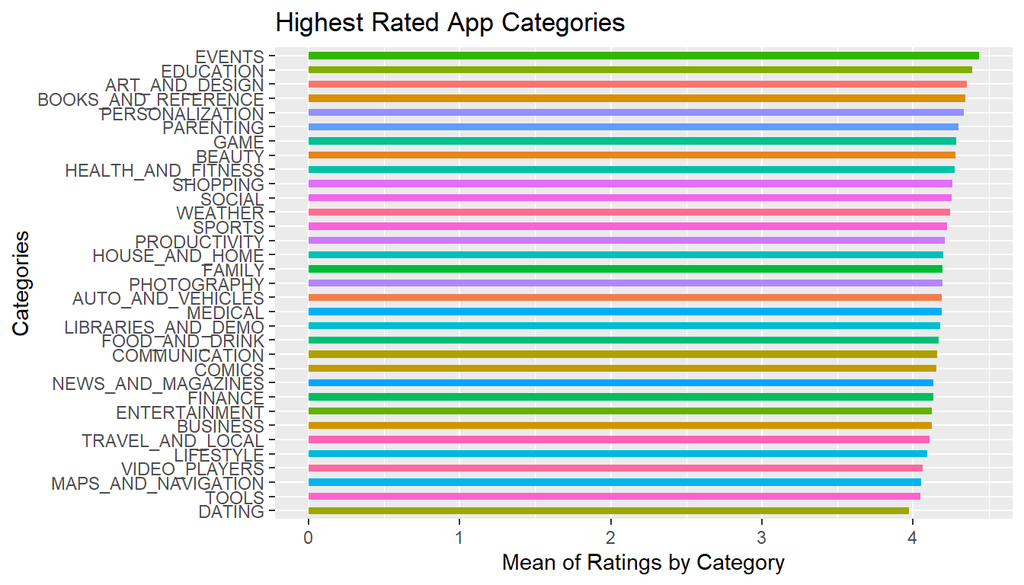

```r
p<-ggplot(xx,aes(x=reorder(Category,means),y=means,fill=Category))+geom_bar(stat = "identity",width =0.5)+coord_flip()+labs(title="Highest Rated App Categories",x="Categories",y="Mean of Ratings by Category")
p+theme(legend.position = "None")
```

## total reviews per app category

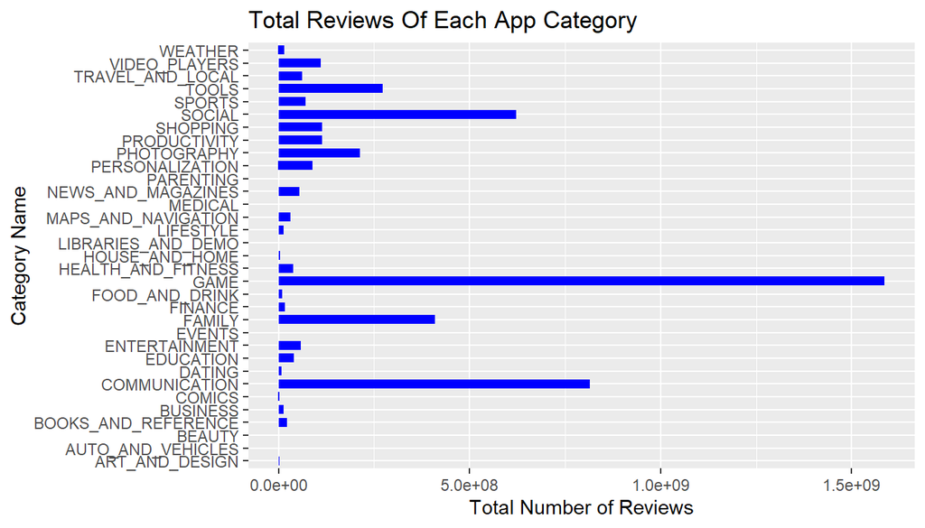

```r
ggplot(data.clean,aes(x=Category,y=Reviews)) +
  geom_bar(stat = "identity",width = 0.7,fill="blue")+
  coord_flip()+
  ggtitle("Total Reviews Of Each App Category")+
  xlab("Category Name")+
  ylab("Total Number of Reviews")
```

## category vs reviews

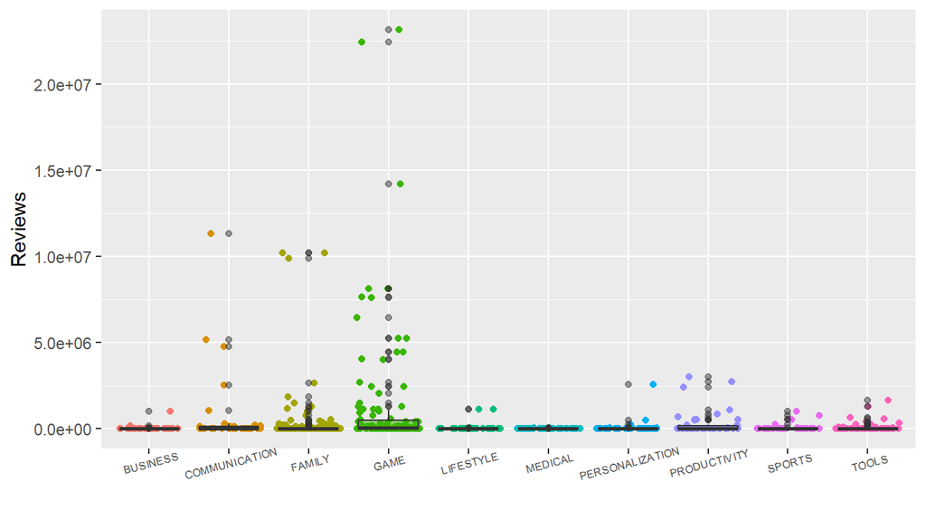

```r
data.clean %>%
filter(Category==c("FAMILY","GAME","TOOLS","MEDICAL","BUSINESS","PRODUCTIVITY","PERSONALIZATION","COMMUNICATION","SPORTS","LIFESTYLE"))%>%
ggplot(aes(Category,as.numeric(Reviews)))+geom_jitter(aes(color=Category))+geom_boxplot(aes(fill=Category),alpha=1/2)+
theme(axis.text.x = element_text(angle = 15,hjust = 0.5, size =6))+
theme(legend.position="none")+xlab("")+ylab("Reviews")+
scale_x_discrete(labels = function(x) str_wrap(x, width = 2))
```

## ratings

```r
dataset<-read.csv("D:\\play store\\googleplaystore.csv")
dataset$Installs <- str_replace_all(dataset$Installs,",","")
dataset$Installs <- as.numeric(dataset$Installs)
dataset$Reviews <- as.numeric(dataset$Reviews)
#Cleaning 2
##Converting "M" and "K" and changing it to numeric format
dataset$Size <- str_replace_all(dataset$Size,"M","")
dataset$Size <- str_replace_all(dataset$Size,"k","")
dataset$Size <- as.numeric(dataset$Size)
dataset[is.na(dataset$Size),"Size"] <- median(dataset$Size,na.rm=T)

#Converting "$"
#The Price column has "$" in it.Since this is a special character "[]" has to be mentioned for it.
dataset$Price <- str_replace_all(dataset$Price,"[$]","")

#Cleaning 3
#We can use nested ifelse to convert into category.
Install_Category<-ifelse(dataset$Installs <10001,"Grade D",ifelse(dataset$Installs <1000001,"Grade C",ifelse(dataset$Installs <100000001,"Grade B","Grade A")))
Install_Category <- factor(Install_Category,levels = c("Grade D","Grade C","Grade B","Grade A"))
dataset<- cbind(dataset,as.data.frame(Install_Category))

#Cleaning 4
#The mdy specifies the Month Day Year.
dataset$Last.Updated<-mdy(dataset$Last.Updated)
dataset$Year.Updated<-year(dataset$Last.Updated)
dataset$Month.Updated<-month(dataset$Last.Updated)
#Now we dont need the Last.Updated Field hence Removing it
dataset$Last.Updated<- NULL
```

## density of app ratings

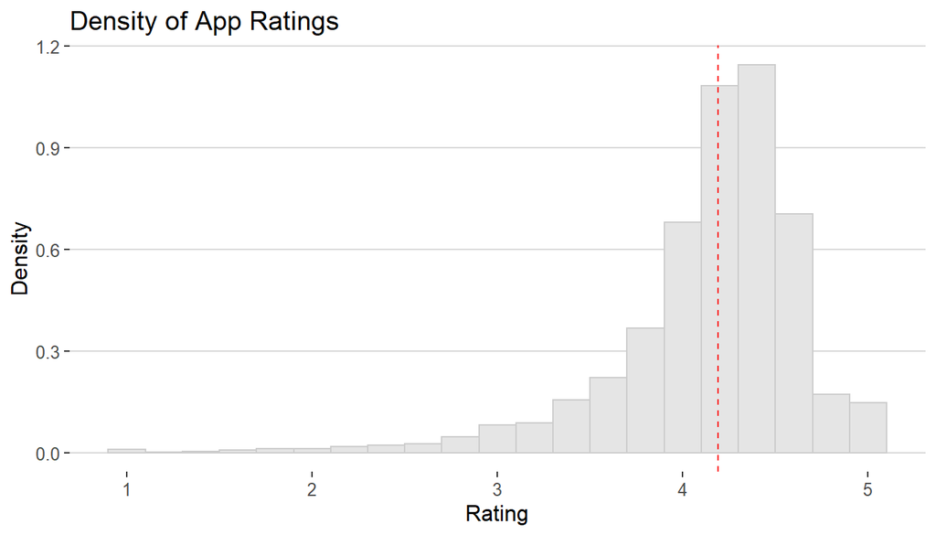

```r
ggplot(data=subset(data.clean,!is.na(Rating)), aes(x = Rating,na.rm=TRUE)) +
    geom_histogram(aes(y = ..density..), binwidth = 0.2, fill = 'grey90', color = 'grey80') +
    geom_vline(aes(xintercept = mean(Rating)), color = 'red', linetype = "dashed") +
    labs(x = 'Rating', y = 'Density', title='Density of App Ratings') +
    theme_hc()
```

#### Looking at the density histogram above, we can see that the majority of ratings fall between roughly 3.8 and 4.6.

## Mean Ratings of Applications

```r
mean(data$Rating,na.rm=TRUE)
```

```
## [1] 4.191757
```

#### on average, we see that the mean of app rating is 4.191

```r
library(scales)
```

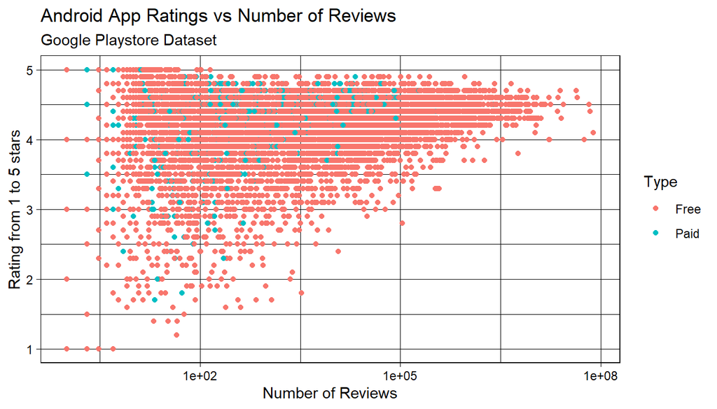

```r
library(ggplot2)
#scales library for log values to be displayed as natural numbers
ggplot(data.clean, aes(x=Reviews, y=Rating)) +scale_x_continuous(trans='log10') +
  geom_point(aes(col=Type)) +
  labs(title="Android App Ratings vs Number of Reviews", subtitle="Google Playstore Dataset", y="Rating from 1 to 5 stars", x="Number of Reviews") +
  theme_linedraw()
```

## correlation model

```r
library(corrplot)
str(data.clean)
```

```
## 'data.frame':    10839 obs. of  13 variables:
##  $ App            : chr  "Photo Editor & Candy Camera & Grid & ScrapBook" "Coloring book moana" "U Launcher Lite â\200“ FREE Live Cool Themes, Hide Apps" "Sketch - Draw & Paint" ...
##  $ Category       : chr  "ART_AND_DESIGN" "ART_AND_DESIGN" "ART_AND_DESIGN" "ART_AND_DESIGN" ...
##  $ Rating         : num  4.1 3.9 4.7 4.5 4.3 4.4 3.8 4.1 4.4 4.7 ...
##  $ Reviews        : num  159 967 87510 215644 967 ...
##  $ Size           : num  19 14 8.7 25 2.8 5.6 19 29 33 3.1 ...
##  $ Installs       : num  1e+04 5e+05 5e+06 5e+07 1e+05 5e+04 5e+04 1e+06 1e+06 1e+04 ...
##  $ Type           : chr  "Free" "Free" "Free" "Free" ...
##  $ Price          : num  0 0 0 0 0 0 0 0 0 0 ...
##  $ Content.Rating : chr  "Everyone" "Everyone" "Everyone" "Teen" ...
##  $ Genres         : chr  "Art & Design" "Art & Design;Pretend Play" "Art & Design" "Art & Design" ...
##  $ Last.Updated   : Date, format: "2018-01-07" "2018-01-15" ...
##  $ Current.Ver    : chr  "1.0.0" "2.0.0" "1.2.4" "Varies with device" ...
##  $ Min.Android.Ver: num  4 4 4 4.2 4.4 2.3 4 4.2 3 4 ...
```

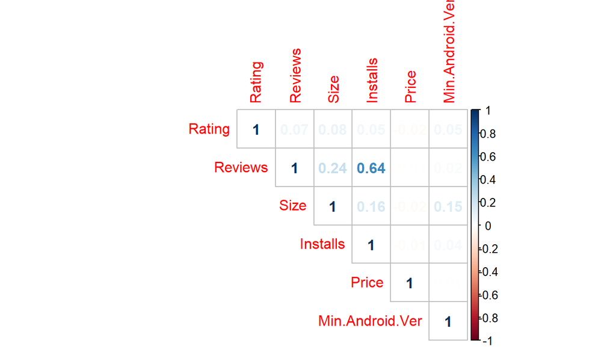

```r
data_num <- data.clean[,c("Rating", "Reviews", "Size","Installs","Price","Min.Android.Ver")]
corr <- cor(data_num,use="pairwise.complete.obs")
corrplot(corr, method='number',type="upper")
```

## Analyzing how size of the app matters for it to have a higher rating

```r
tmp <- data.clean %>%
    group_by(Rating) %>%
    summarise(avg_size = mean(Size,  na.rm=TRUE)) %>%
    arrange(desc(avg_size))
```

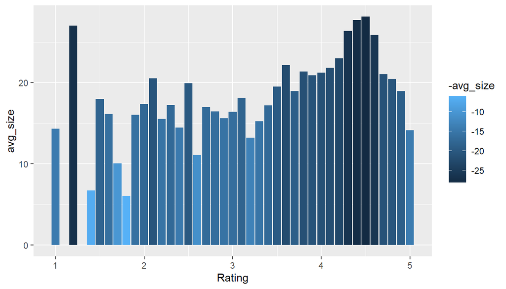

```r
ggplot(tmp, aes(x=Rating, y = avg_size, fill = -avg_size))+
    geom_col()
```

#### we cannot deduce much from this graph as we see that apps rating is all over the place irrespective of size. hence, we can conclude that the “quality” of the app matters and not its size.

## Analyzing how price of the app matters for it to have a higher rating

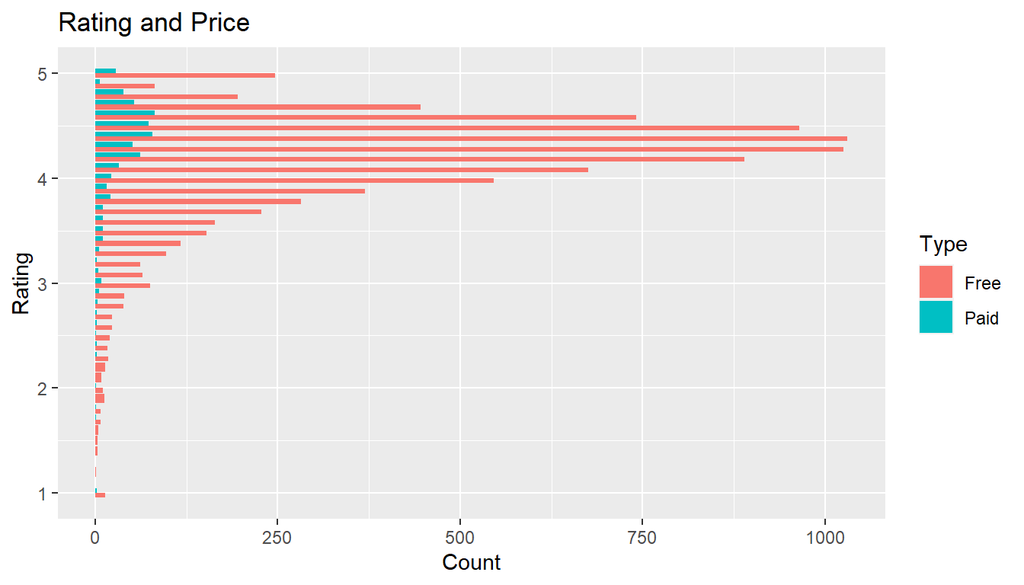

```r
ggplot(data.clean, aes(x = Rating, fill = Type))+
    geom_bar(stat = "Count", position = "dodge")+
    xlab("Rating")+
    ylab("Count")+
    labs(title = "Rating and Price")+
    coord_flip()
```

#### we see that for paid apps, its quite rare for them to have less rating. Hence, we can understand that users paying for these apps do their research beforehand before making their purchases and then give reviews. for free apps, we see that most apps have a rating from 3.8 to 4.6 which we have deduced earlier but this comparison gives us a good insight between the free and paid apps.

## content rating table

```r
table(data.clean$Content.Rating)
```

```
##
## Adults only 18+        Everyone    Everyone 10+      Mature 17+            Teen
##               3            8714             413             499            1208
##         Unrated
##               2
```

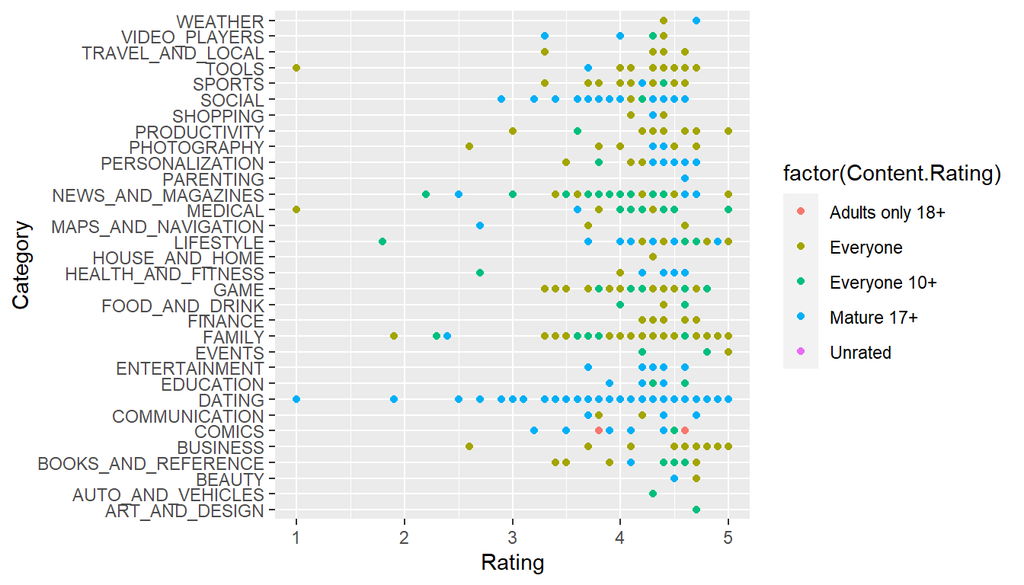

```r
ggplot(data[which(data.clean$Content.Rating!="Everyone"&data$Content.Rating!="Teen"),], aes(x=Category, y=Rating))+geom_point(aes(colour=factor(Content.Rating)))+coord_flip()
```

## Boxplot between rating and app categories

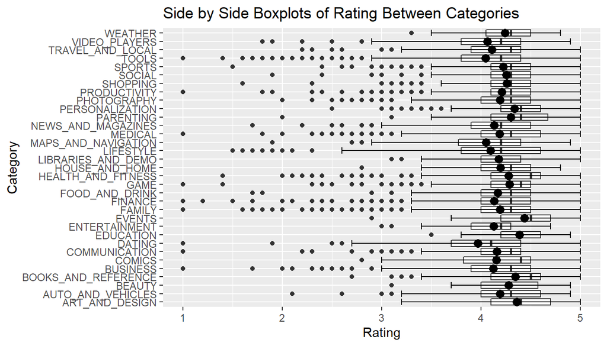

```r
ggplot(data.clean, aes(x = Category, y = Rating)) +
  geom_boxplot() +
  stat_boxplot(geom = "errorbar") +
  stat_summary(fun.y = mean, col = "black", geom = "point", size = 3) +
  ggtitle("Side by Side Boxplots of Rating Between Categories")+coord_flip()
```

## Do App Ratings Differ Per Genre?

#### H0 : The genre of an app does not have any significant impact on its rating.

####HA : App ratings differ based on their genre.

####To test this hypothesis, we can begin by observing the distribution of Rating over Genre using a boxplot. Due to the number of genres, the plot is a little messy, so I’ve used colors, alpha, and jittering to make it a little better.

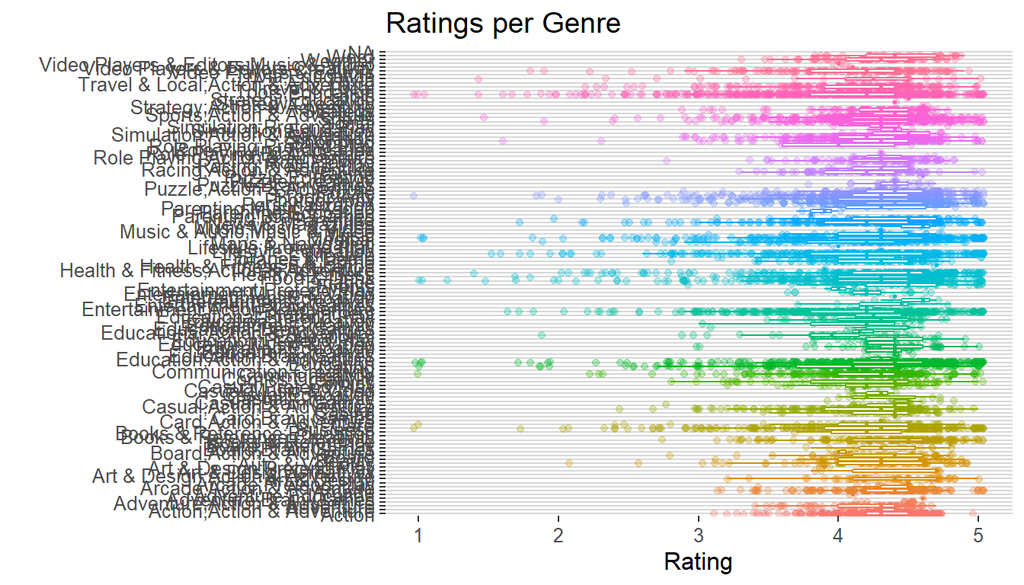

```r
ggplot(data, aes(x = Genres, y = Rating, color = Genres)) +
    geom_jitter(alpha = 0.3, width = 0.1) +
    geom_boxplot(outlier.color = NA) +
    geom_hline(aes(yintercept = mean(Rating)), color = 'black', linetype = 'dashed') +
    coord_flip() +
    labs(x = '', y = 'Rating', title = 'Ratings per Genre') +
    theme_hc() +
    theme(legend.position = 'none')
```

#### We can see from this visual plot that the means differ, but is it significant? Of note is the great number of outliers. I think that given the domain we’re working in here - app ratings on popular mobile platform - deviation like this is expected. Let’s now run an ANOVA test to see if there’s any statistically significant difference. I am not concerned with which differs, only that there is a difference.

```r
rating_genre_aov <- aov(Rating ~ Genres, data = data.clean)
summary(rating_genre_aov)
```

```
##               Df Sum Sq Mean Sq F value Pr(>F)
## Genres       114    103  0.9036   3.508 <2e-16 ***
## Residuals   9251   2383  0.2576
## ---
## Signif. codes:  0 '***' 0.001 '**' 0.01 '*' 0.05 '.' 0.1 ' ' 1
## 1473 observations deleted due to missingness
```

#### Here, our p-value is very small, so we can reject H0 and conclude that the genre has a statistically significant impact, but is unlikely to be the sole influence upon, the rating of an application. We must be careful here to say that there is an impact, but keep in mind that many other factors could lead to a rise in rating, not just the genre.

## App Rating vs Size

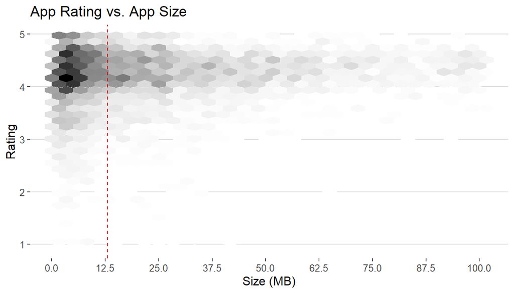

```r
ggplot(data=subset(data.clean,!is.na(Rating)), aes(x = Size, y = Rating)) +
    stat_binhex(show.legend = F) +
    scale_x_continuous(breaks = seq(0, 100, length=9)) +
    geom_vline(xintercept = median(data.clean$Size, na.rm=TRUE), color = 'red', linetype = 'dashed') +
    theme_hc() +
    scale_fill_gradient(low = 'white', high = 'black') +
    labs(title = 'App Rating vs. App Size', x = 'Size (MB)')
```

## App rating vs Review Count

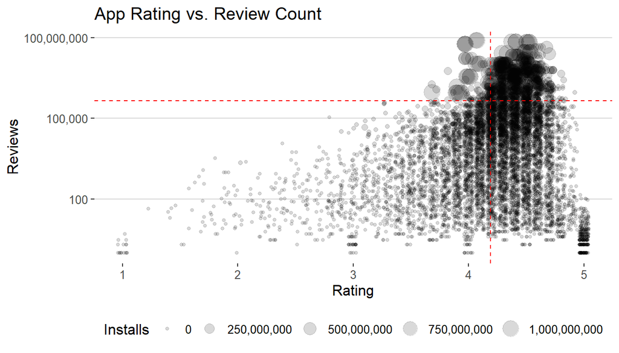

```r
ggplot(data.clean, aes(x = Rating, y = Reviews, size = Installs)) +
    geom_jitter(alpha = 0.15) +
    scale_y_log10(labels = scales::comma) +
    scale_size_continuous(labels = scales::comma) +
     geom_vline(xintercept = mean(data.clean$Rating,na.rm=TRUE), color = 'red', linetype = 'dashed') +
     geom_hline(yintercept = mean(data.clean$Reviews,na.rm=TRUE), color = 'red', linetype= 'dashed') +
    theme_hc() +
    labs(title = 'App Rating vs. Review Count')
```

#### The plot above explores Rating on Reviews. Scales in the Y axis have been logged due to the outliers that have an extortionate number of reviews, yet are perfectly valid in our data set (i.e., apps that have gone viral).

#### The size of the points is linked to the number of installs that app has. If we look in the top-right, we can see the majority of large points. This makes sense, as higher install count is likely to generate a higher review count, and given that the applications are obviously popular, they are also likely to have a decent rating, which most of them do.

#### The dense area of the plot lies between ~3.8 and ~4.75 on the Rating axis, which matches our previous estimate of the average rating. If we read the graph from the bottom up at this location, we can see the density increase gradually as apps approach 100k reviews. This again suggests that applications with a large user base (and therefore large number of reviews) increses the chances of having a good rating, although this is not given. This is of course a very high-level overview and more rigerous analysis would have to be done to determine if such correlations have any true meaning.

## App rating vs Length of app name

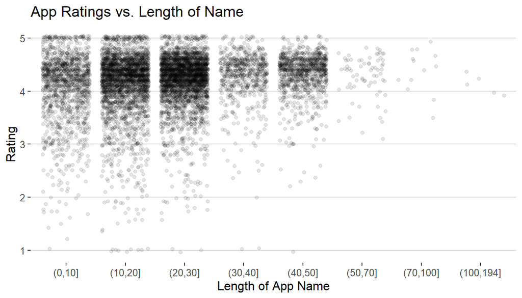

```r
data.clean %>%
    mutate(NameLength = nchar(App)) %>%
    select(NameLength, Rating) %>%
ggplot(aes(x = cut(NameLength, breaks=c(0, 10, 20, 30, 40, 50, 70, 100, max(NameLength))), y = Rating)) +
    geom_jitter(alpha = 0.1) + theme_hc() +
    labs(x = 'Length of App Name', title='App Ratings vs. Length of Name')
```

#### This graph is a little silly, but nonetheless does provide some insight. We can see that, in accordance with our other findings, the hotspots are around high 3 to mid 4. However, there is a clear density with app names ranging from 10-30 characters in length. This suggests a relationship other than rating; perhaps that applications with short and overly-long names are not installed as much, and therefore do not receive as many (or as high) ratings. We can further explore this by repeating the above graph with respect to install count.

## App Installs vs Length of Name

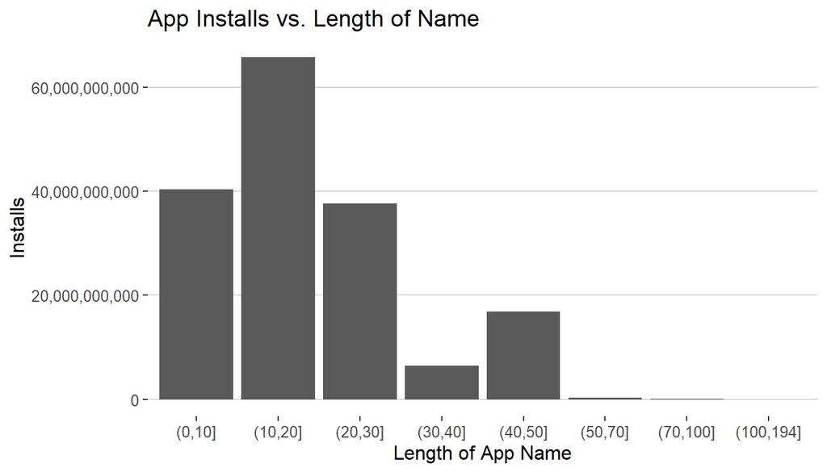

```r
data.clean %>%
    mutate(NameLength = nchar(App)) %>%
    select(NameLength, Installs) %>%
ggplot(aes(x = cut(NameLength, breaks=c(0, 10, 20, 30, 40, 50, 70, 100, max(NameLength))), y = Installs)) +
    geom_col() +
    scale_y_continuous(labels = scales::comma) +
    theme_hc() +
    labs(x = 'Length of App Name', title='App Installs vs. Length of Name')
```

## Do App ratings differ with price

#### And finally, do app ratings differ with price boundaries? Note that one app, Vargo Anesthesia Mega App, is priced at 79.99. I’m removing this as an outlier to simlpify the graph. The closest price to it is ~40.

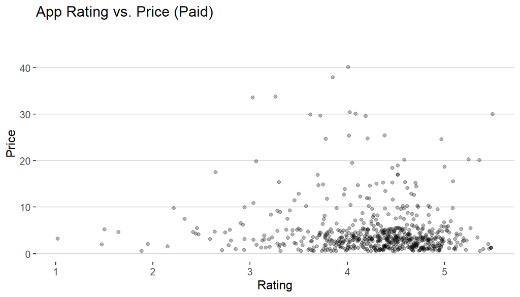

```r
data.clean %>%
    filter(Type == 'Paid', Price < 60) %>%
ggplot(aes(x = Rating, y = Price)) +
    geom_jitter(height=0.5, width=0.5, alpha = 0.3) +
    theme_hc() +
    labs(title='App Rating vs. Price (Paid)')
```

## Future Works

#### We can assess all the observation and analysis made, combine more datasets into the test dataset and train a model which will help us to predict whether an application will be feasible on the play store or not depending on its attributes.